# Confidence Intervals (Section 3.2) and Bootstrapping (3.3)

Day 10

Claire Kelling

Carleton College  
STAT 120 - Fall 2026

## Question of the Day

Do you prefer hot or cold apple cider? (or neither??)

## Today’s Topics

Logistics:

- Short Report due on Friday! Questions?
- Knit **today!** Files you need to submit: report (pdf), Rmd, and knitted Rmd (pdf).
- Quiz 1 Corrections: due 2 weeks from today! **This is an individual effort!**
- Pink sheets!

Topics covered today:

- Confidence Intervals (Section 3.2)

# Confidence Intervals

## Example: Russian Political Polling

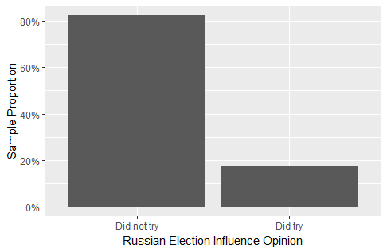

- What do we want to know?
  - $p$ = proportion of Russian citizens who think their government influenced the election
- What do we know?
  - Sample proportion of those who thought they did try to influence the election: $\hat{p} = 17.5\%$
- **How accurate is 17.5%?**

## Interval Estimate

An **interval estimate** gives a range of plausible values for a population parameter.

The most common form for an interval estimate is:

statistic $\pm$ margin of error

The **margin of error** reflects the precision of the sample statistic as a point estimate for the parameter.

## Margin of Error- Okay Example

[figure not shown]

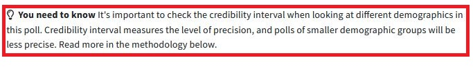

## Margin of Error- Bad Example

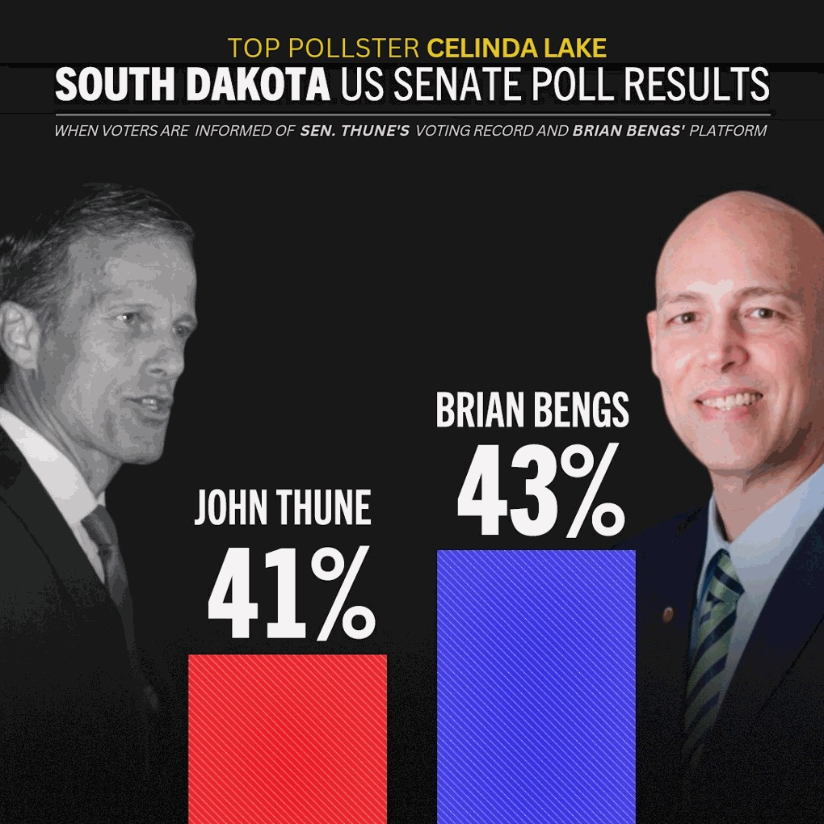

- Let’s pretend they gave us a margin of error.
  - “The margin of sampling error is +/- 3 percentage points at the 95% confidence level.” (from a Gallup poll)
- Bengs interval estimate: 43% $\pm$ 3% = (40%, 46%)
- **Interpretation:** We are *pretty sure* that the % of people in South Dakota voting for Bengs is between 40% and 46%.
- Is the difference between Bengs and his opponent distinguishable?

## Margin of Error

How do we determine the margin of error?

1. The statistic’s sampling distribution and associated standard error
2. A measure of “confidence”
   - How sure do we want to be?

## Confidence Intervals

- **StatKey** can be used to illustrate confidence intervals through a sampling distribution simulation
- The parameter is fixed
- The statistic is random (depends on the sample)
- The interval is **also random** (depends on the sample/statistic)
- For this simulation, 97 out of 100 samples yield intervals that capture the parameter.

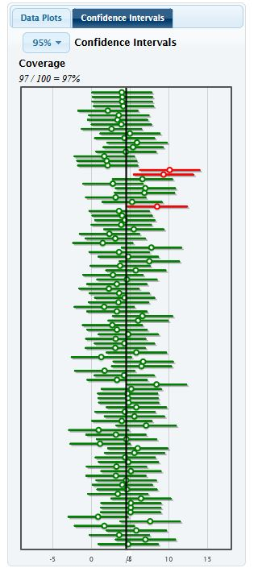

## Confidence

- The confidence level tells us what **proportion of samples** of a given size will give a sample statistic that is **within the** **margin of error** (MOE) of the **population parameter.**
- A 95% confidence interval will contain the true parameter for 95% (approximately) of all samples
- “…the margin of error is +/- 3 percentage points at the 95% confidence level.”
  - What does this mean?
- 95% confidence means that approximately 95% of all samples will yield a sample proportion that is within 3 percentage points of the population proportion.

## 95% Confidence Interval

If the sampling distribution is relatively symmetric and bell-shaped, a 95% confidence interval can be estimated using

statistic $\pm$ 2 $\times$ SE

**“95% confidence”** means 95% of all samples will yield a statistic that is within 2 SE of the population parameter.

- Reminder: what is the margin of error for a 95% CI?

## Interpreting a Confidence Interval

Interpreting a Confidence Interval (CI) from **one** sample:

95% of all samples yield intervals that contain the true parameter, so we say we are “95% sure” or “95% confident” that one interval contains the truth.

**Bengs:**

**Interpretation language:** We are 95% confident that the proportion of South Dakotans that will vote for Bengs is between 40% and 46%.

## Step by Step Interpretation

An interpretation structure for CIs to avoid misinterpretation:

One parameter (ex: mean)

1. I am 95% sure/confident
2. that the **population parameter** **of interest in context**
3. is between (#) and (#) **units.**

**Example**: I am 95% confident that the mean commute time for all US adults is between 30 and 60 minutes. CI: (30, 60)

## Practice Example: Carbon in Forest Biomass

- Scientists hoping to curb deforestation estimate that the carbon stored in tropical forests in Latin America, sub-Saharan Africa, and southeast Asia has a total biomass of 247 gigatons.
- To arrive at this estimate, they first estimate the mean amount of carbon per square kilometer.
- Based on a sample of size n = 4079 inventory plots, the sample mean is 11,600 tons with a standard error of 1000 tons.

Give and interpret a 95% confidence interval for the mean amount of carbon per square kilometer.

Saatchi, S.S. et. al. “Benchmark Map of Forest Carbon Stocks in Tropical Regions Across Three Continents,” Proceedings of the National Academy of Sciences, 5/31/11.

## Practice Example: Carbon in Forest Biomass

- 95% CI: 11,600 $\pm$ 2 $\times$ 1,000 = (9,600, 13,600)
- We are 95% confident that the average amount of carbon stored in each square kilometer of tropical forest is between 9,600 and 13,600 tons.

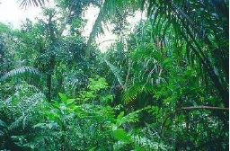

## Differences in Parameters

|  | Parameter | Statistic |
| --- | --- | --- |
| Mean | $\mu$ (mu) | $\bar{x}$ (x bar) |
| Proportion | $p$ | $\hat{p}$ |
| Std. Dev. | $\sigma$ | $s$ |
| Correlation | $\rho$ (rho) | r |
| Slope | $\beta$ | $b$ |

- Read the question context to determine if you are estimating a mean or a proportion.
- If you are interested in the difference between two means, you would write $\mu_1 - \mu_2$ as your population parameter of interest (or something more informative like $\mu_{2015} - \mu_{1994}$) which is then estimated with $\bar{x_1} - \bar{x_2}$. Similar idea with proportions.

## Step by Step Interpretation

An interpretation structure for CIs to avoid misinterpretation:

Two parameters (ex: difference in means)

1. I am 95% sure/confident
2. that the **population parameter 1** **of interest in context**
3. is between (#) (less/greater) and (#) (less/greater) **units** than
4. **population parameter 2** **of interest in context**.

**Example**: I am 95% confident that the mean test score for left-handed people is between 5 to 10% greater than the mean test score for right-handed people. CI: (5%, 10%)

**Example**: I am 95% confident that the mean test score for left-handed people is between 5% lower to 6% greater than the mean test score for right-handed people. CI: (-5%, 6%)

## Practice Example: Gun Ownership

- In 1994, a random sample of US adults found 9% of females owned a gun. A similar sample in 2015 found 12% of females owned a gun.
- The standard error for the *difference in the two rates* is 2%.
- What is the 95% confidence interval for the difference in the proportion of female gun owners from 1994 to 2015?

statistic $\pm$ 2 $\times$ SE = (0.12 – 0.09) $\pm$ 2 $\times$ 0.02

0.03 ± 0.04 = (-0.01, 0.07)

- Interpret the CI using a directional statement. (Is one higher than the other?)

I am 95% confident that the prop female gun ownership in 2015 is between a 1% decrease to a 7% increase from the prop female gun ownership in 1994.

## Practice Example: Gun Ownership

Is one higher than the other?

I am 95% confident that the prop female gun ownership in 2015 is between a 1% decrease to a 7% increase from the prop female gun ownership in 1994.

The CI includes 0, so we are not confident the proportion has changed (that the $p_{2015}$ and $p_{1994}$ are different), given this data. The actual population difference in proportions could be negative, 0, or positive.

## !!! Common Misinterpretations !!!

1. Misinterpretation 1: “A 95% confidence interval contains 95% of the data in the population”
2. Misinterpretation 2: “I am 95% sure that the mean of a sample will fall within a 95% confidence interval for the mean”
3. Misinterpretation 3: “The probability that the population parameter is in this particular 95% confidence interval is 0.95”
   - In this class, this means that the parameter is in the CI 95% of the time
   - Once you have your data, the CI either contains the parameter or it doesn’t

## Examples: Correct or Incorrect?

**Example 1**

A 98% confidence interval for mean pulse rate is 65 to 71. The interpretation “I am 98% sure that all students will have pulse rates between 65 and 71 bpm.” Incorrect: Misinterpretation 1.

**Example 2**

A 98% confidence interval for mean pulse rate is 65 to 71. The interpretation “I am 98% sure that the mean pulse rate for the population of all students will fall between 65 and 71 bpm.” Correct! Talking about the population parameter.

**Example 3**

A 98% confidence interval for mean pulse rate is 65 to 71. The interpretation “There is a 98% chance that the mean pulse rate for the population of all students will fall between 65 and 71 bpm.” Incorrect: Misinterpretation 3.

**Example 4**

A 98% confidence interval for mean pulse rate is 65 to 71. The interpretation “I am 98% sure that the mean pulse rate for this sample of students will fall between 65 and 71 bpm.” Incorrect: Misinterpretation 2.

## Summary (Section 3.2)

To create a 95% confidence interval for a parameter:

- Take a random sample from the population to get a point estimate for the parameter.
- Then take many random samples from the population, and compute the sample statistic for each sample. Compute the standard error as the standard deviation of all these statistics
- 95% CI is equal to: statistic $\pm$ 2 $\times$SE
- Be careful about interpretation.

## The problem

- In the real world, we only have one sample!
- How do we know how much sample statistics vary (SE), if we only have one sample??

## Next Class

Bootstrap Confidence Intervals